# Assessing injury on GOM cetaceans

## 5.2 Injury metrics

In the following table we present the means of the 3 injury metrics:

Injury results for the different stocks considered.

| Sp | LCY | MPD | YTR |
| --- | --- | --- | --- |
| Bwsp | 1321 | -0.038 | 1.6 |
| Fatt | 1250 | -0.042 | 2.3 |
| Ggri | 2449 | -0.057 | 7.3 |
| Gmac | 1058 | -0.035 | 1.2 |
| Kosp | 1429 | -0.052 | 4.9 |
| Pele | 3072 | -0.042 | 2.1 |
| Pmac | 2549 | -0.064 | 9.7 |
| Satt | 33810 | -0.035 | 0.6 |
| Sbre | 2434 | -0.040 | 1.6 |
| Scly | 1902 | -0.018 | 0.0 |
| Scoe | 3715 | -0.059 | 7.1 |
| Sfro | 7509 | -0.013 | 0.0 |
| Slon | 17715 | -0.089 | 11.2 |
| Ttro | 11370 | -0.057 | 6.6 |
| Ttrs | 35190 | -0.042 | 2.4 |

In the following table we present the medians and the 95% confidence intervals for our current estimates of injury. These correspond to the results in table 3 in the main paper.

Median injury results for the different stocks considered and respective 95% confidence intervals by the percentile method

| Sp | LCYmed | LCYl | LCYu | MPDmed | MPDl | MPDu | YTRmed | YTRl | YTRu |
| --- | --- | --- | --- | --- | --- | --- | --- | --- | --- |
| Bwsp | 1207 | 445 | 2899 | 3.683 | 1.386 | 6.951 | 0 | 0 | 11 |
| Fatt | 1122 | 437 | 2809 | 4.186 | 1.939 | 6.642 | 0 | 0 | 13 |
| Ggri | 2264 | 978 | 5049 | 5.623 | 2.569 | 9.494 | 8 | 0 | 18 |
| Gmac | 964 | 385 | 2291 | 3.435 | 1.486 | 6.216 | 0 | 0 | 12 |
| Kosp | 1294 | 519 | 3112 | 5.114 | 2.315 | 8.492 | 5 | 0 | 14 |
| Pele | 2761 | 1081 | 6767 | 4.140 | 1.925 | 6.601 | 0 | 0 | 12 |
| Pmac | 2356 | 996 | 5240 | 6.344 | 2.672 | 10.189 | 11 | 0 | 21 |
| Satt | 31372 | 12884 | 67606 | 3.433 | 1.563 | 5.615 | 0 | 0 | 9 |
| Sbre | 2232 | 901 | 5207 | 3.995 | 1.836 | 6.349 | 0 | 0 | 11 |
| Scly | 1726 | 664 | 4067 | 1.734 | 0.747 | 3.261 | 0 | 0 | 0 |
| Scoe | 3387 | 1369 | 7897 | 5.673 | 2.479 | 10.426 | 8 | 0 | 17 |
| Sfro | 6961 | 2722 | 15509 | 1.264 | 0.542 | 2.280 | 0 | 0 | 0 |
| Slon | 15255 | 5302 | 44903 | 8.363 | 3.277 | 17.716 | 12 | 0 | 21 |
| Ttro | 10537 | 4597 | 23220 | 5.610 | 2.546 | 9.125 | 8 | 0 | 16 |
| Ttrs | 32584 | 13377 | 71967 | 4.152 | 1.859 | 6.758 | 0 | 0 | 13 |

These are the values that are used in table 3 of the paper, and the code to do so is in the .Rmd.

Representing the above information visually, focusing on each of the 3 injury metrics:

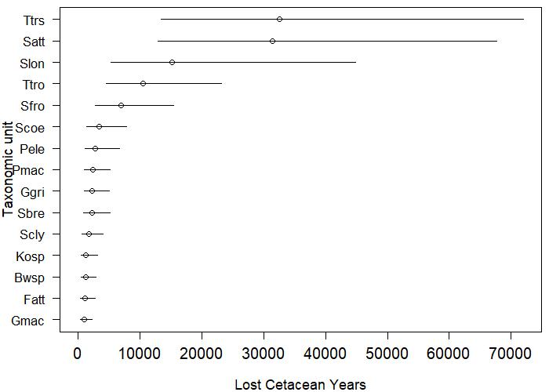

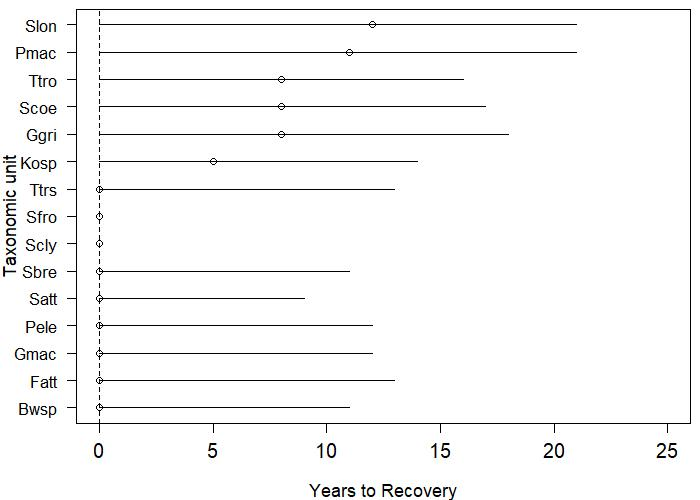

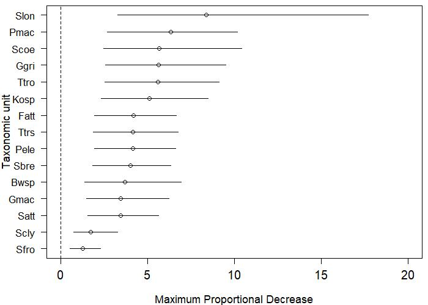

# 6 Exploring the injury metric results

In this section we explore the results obtained in terms of the different injury metrics and how these injury metrics might be explained by the different input parameters. To do so we consider linear models to model the mean value of the injury per species as a function of the mean values of the input parameters. After a preliminary exploratory analysis, only the following four parameters seem to have a non-negligible potential relevant effect on the injury metrics:

- Proportion Exposed
- Initial population size
- Gestation duration
- Survival reduction

## 6.1 Exploratory analysis

Here we plot the values of the injury metrics as a function of the four key parameters going into the model.

### 6.1.1 Proportion exposed

The next three plots describe the relationship between the proportion exposed and Lost Cetacean Years, the Maximum Proportion Decrease and the Years to recovery, respectively

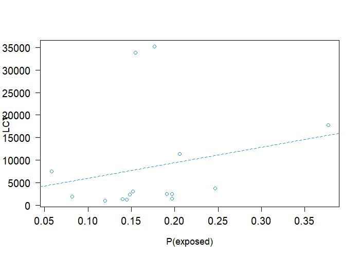

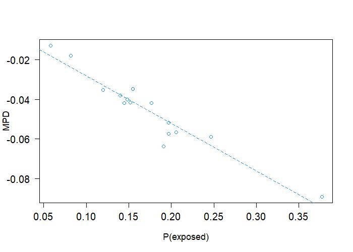

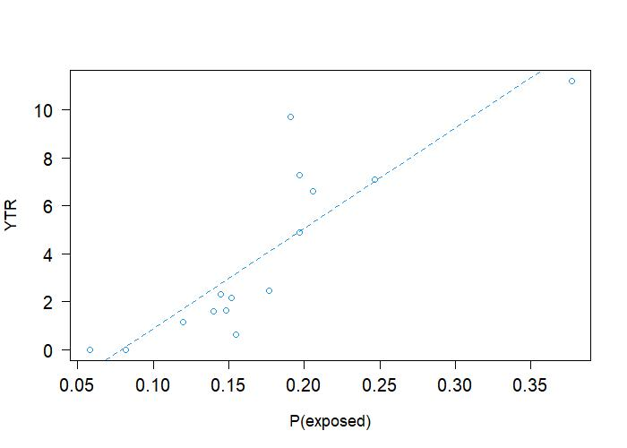

### 6.1.2 Initial population size

The next three plots describe the relationship between the initial population size and Lost Cetacean Years, the Maximum Proportion Decrease and the Years to recovery, respectively.

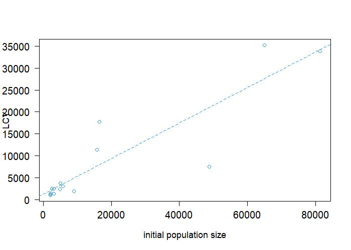

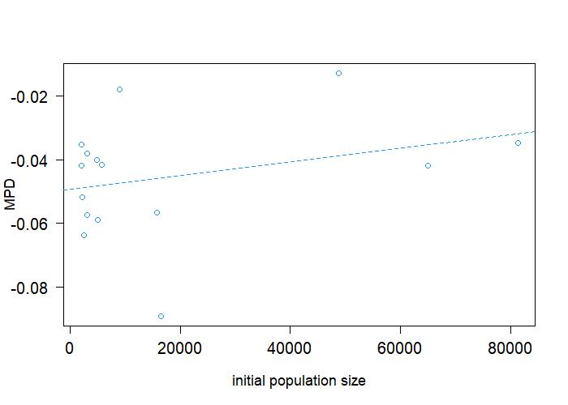

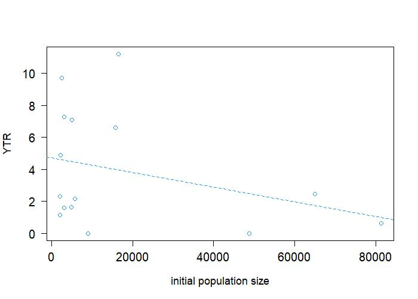

### 6.1.3 Gestation duration

The next three plots describe the relationship between the gestation duration and Lost Cetacean Years, the Maximum Proportion Decrease and the Years to recovery, respectively

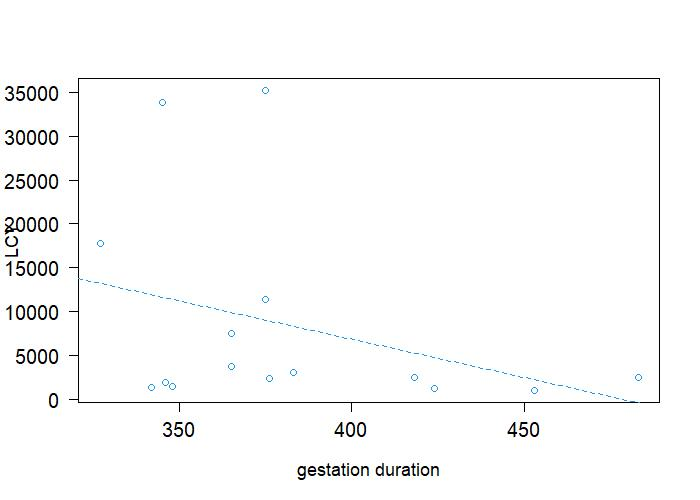

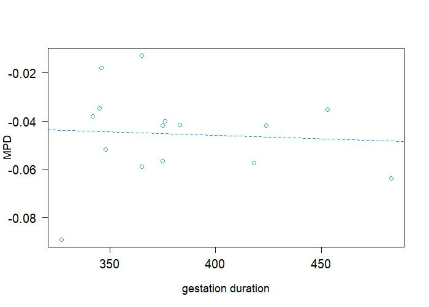

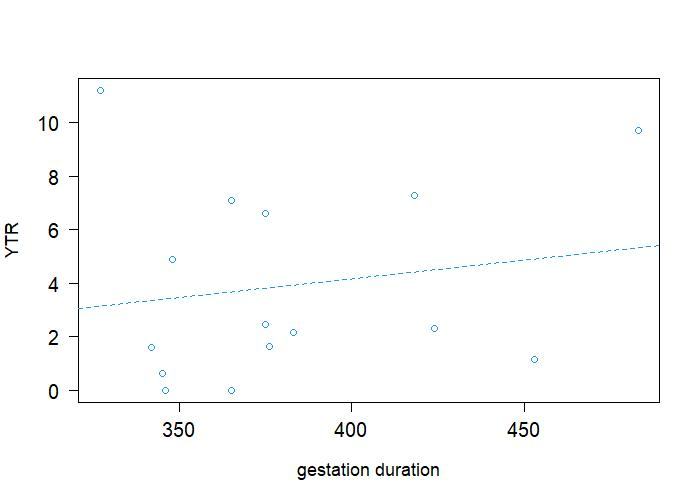

### 6.1.4 Survival reduction

The next three plots describe the relationship between the survival reduction and Lost Cetacean Years, the Maximum Proportion Decrease and the Years to recovery, respectively

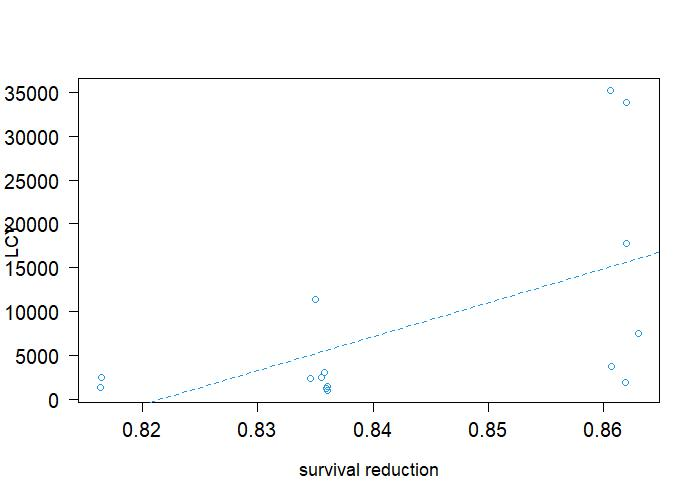

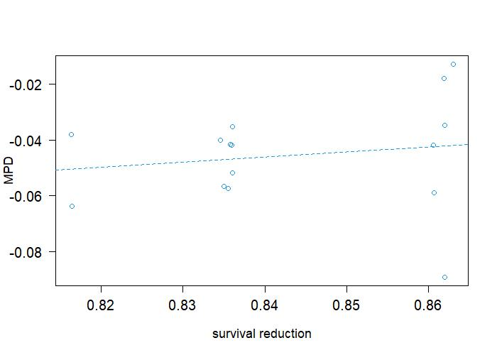

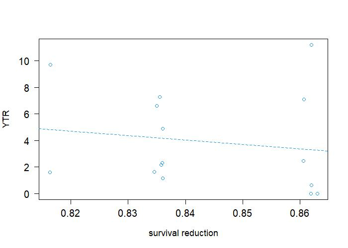

## 6.2 Explaining injury metrics across species

Here we consider standard linear models to explain the injury metrics as a function of the input parameters. To obtain what we considered the most parsimonious model we conducted a traditional model selection approach using AIC, selecting the model with the lowest AIC.

We considered only the 4 explanatory variables which, given the exploratory data analysis above, could explain the injury metrics. Given only 4 explanatory variables, we conducted a full search over the possible models, ignoring interactions, using function bestglm from the package bestglm (McLeod & Lai, 2020).

### 6.2.1 LCY

The summary of the best linear model follows.

```
## AIC
## BICq equivalent for q in (0.00257603089392322, 0.694144062450929)
## Best Model:
##                  Estimate     Std. Error   t value         Pr(>|t|)
## (Intercept) -8585.8086023  2457.09226124 -3.494296 0.00442815340683
## N               0.4263961     0.03567448 11.952412 0.00000005054783
## p           54656.6056191 12278.22336920  4.451508 0.00079078410382
```

```
##
## Call:
## lm(formula = y ~ p + N, data = LCY4bestglm)
##
## Residuals:
##     Min      1Q  Median      3Q     Max
## -7835.4 -1189.7   855.8  1477.7  6430.2
##
## Coefficients:
##                Estimate  Std. Error t value     Pr(>|t|)
## (Intercept) -8585.80860  2457.09226  -3.494     0.004428 **
## p           54656.60562 12278.22337   4.452     0.000791 ***
## N               0.42640     0.03567  11.952 0.0000000505 ***
## ---
## Signif. codes:  0 '***' 0.001 '**' 0.01 '*' 0.05 '.' 0.1 ' ' 1
##
## Residual standard error: 3380 on 12 degrees of freedom
## Multiple R-squared:  0.9263, Adjusted R-squared:  0.9141
## F-statistic: 75.45 on 2 and 12 DF,  p-value: 0.0000001598
```

We can look at the ANOVA table for the most parsimonious model based on lowest AIC criteria.

```
## Analysis of Variance Table
##
## Response: y
##           Df     Sum Sq    Mean Sq  F value        Pr(>F)
## p          1   91857453   91857453   8.0395       0.01502 *
## N          1 1632291730 1632291730 142.8602 0.00000005055 ***
## Residuals 12  137109617   11425801
## ---
## Signif. codes:  0 '***' 0.001 '**' 0.01 '*' 0.05 '.' 0.1 ' ' 1
```

Using the most parsimonious model, the proportion of the variability explained by each input retained in the regression model and the remaining unexplained variation can be obtained from the ANOVA table of the linear regression (as shown above). The proportion of variance explained in Lost Cetacean Years by the initial population size is 87.7 %, while the proportion exposed accounts for 4.94 %. Only 7.37 of the variability remains unexplained.

We illustrate how well the model predicts the observed values in the plot below:

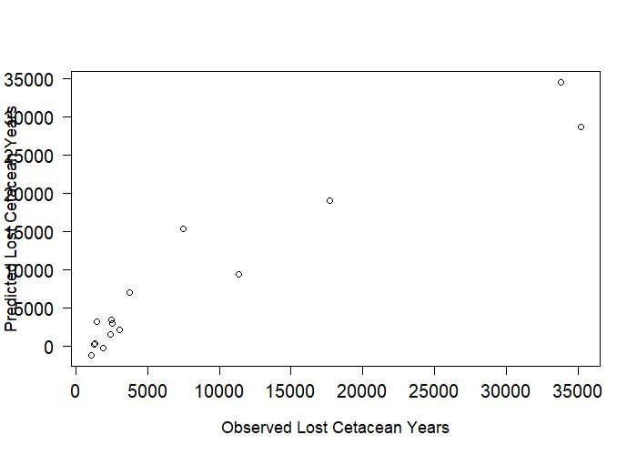

### 6.2.2 YTR

The summary of the best linear model follows.

```
## AIC
## BICq equivalent for q in (0.0565670801885912, 0.714907105110615)
## Best Model:
##                 Estimate  Std. Error   t value       Pr(>|t|)
## (Intercept) -14.46579200 3.864204450 -3.743537 0.002803820209
## gd            0.02778531 0.009303748  2.986464 0.011348598337
## p            44.99620475 5.546928494  8.111914 0.000003260501
```

```
##
## Call:
## lm(formula = y ~ p + gd, data = YTR4bestglm)
##
## Residuals:
##    Min     1Q Median     3Q    Max
## -2.364 -1.229  0.256  1.220  2.177
##
## Coefficients:
##               Estimate Std. Error t value   Pr(>|t|)
## (Intercept) -14.465792   3.864204  -3.744     0.0028 **
## p            44.996205   5.546928   8.112 0.00000326 ***
## gd            0.027785   0.009304   2.986     0.0113 *
## ---
## Signif. codes:  0 '***' 0.001 '**' 0.01 '*' 0.05 '.' 0.1 ' ' 1
##
## Residual standard error: 1.515 on 12 degrees of freedom
## Multiple R-squared:  0.8502, Adjusted R-squared:  0.8253
## F-statistic: 34.06 on 2 and 12 DF,  p-value: 0.00001129
```

We can look at the ANOVA table for the most parsimonious model based on lowest AIC criteria.

```
## Analysis of Variance Table
##
## Response: y
##           Df  Sum Sq Mean Sq F value      Pr(>F)
## p          1 135.955 135.955  59.199 0.000005592 ***
## gd         1  20.483  20.483   8.919     0.01135 *
## Residuals 12  27.559   2.297
## ---
## Signif. codes:  0 '***' 0.001 '**' 0.01 '*' 0.05 '.' 0.1 ' ' 1
```

The proportion of variance explained in Years to Recovery by the proportion exposed is 73.89 %, while the gestation duration accounts for 11.13 %. About 14.98 % of the total variability remains unexplained.

We illustrate how well the model predicts the observed values in the plot below:

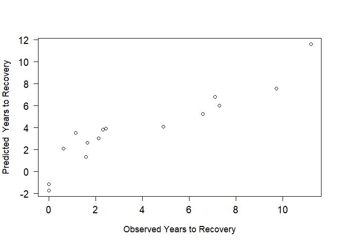

### 6.2.3 MPD

The summary of the best linear model follows.

```
## AIC
## BICq equivalent for q in (0.000138724406806179, 0.794786881122084)
## Best Model:
##                  Estimate    Std. Error    t value              Pr(>|t|)
## (Intercept) -0.1392041611 0.02807655404  -4.958022 0.0004301323010814630
## gd          -0.0000668707 0.00001151907  -5.805218 0.0001183823860569915
## sr           0.1927778277 0.03017672791   6.388295 0.0000516346499919114
## p           -0.2509123557 0.00583220633 -43.021859 0.0000000000001304368
```

```
##
## Call:
## lm(formula = y ~ p + gd + sr, data = MPD4bestglm)
##
## Residuals:
##        Min         1Q     Median         3Q        Max
## -0.0018414 -0.0012123  0.0002479  0.0008383  0.0030570
##
## Coefficients:
##                Estimate  Std. Error t value         Pr(>|t|)
## (Intercept) -0.13920416  0.02807655  -4.958         0.000430 ***
## p           -0.25091236  0.00583221 -43.022 0.00000000000013 ***
## gd          -0.00006687  0.00001152  -5.805         0.000118 ***
## sr           0.19277783  0.03017673   6.388 0.00005163464999 ***
## ---
## Signif. codes:  0 '***' 0.001 '**' 0.01 '*' 0.05 '.' 0.1 ' ' 1
##
## Residual standard error: 0.001593 on 11 degrees of freedom
## Multiple R-squared:  0.9943, Adjusted R-squared:  0.9927
## F-statistic: 634.7 on 3 and 11 DF,  p-value: 0.000000000001334
```

We can look at the ANOVA table for the most parsimonious model based on lowest AIC criteria.

```
## Analysis of Variance Table
##
## Response: y
##           Df    Sum Sq   Mean Sq F value             Pr(>F)
## p          1 0.0044337 0.0044337 1746.38 0.0000000000001792 ***
## gd         1 0.0002966 0.0002966  116.82 0.0000003381460875 ***
## sr         1 0.0001036 0.0001036   40.81 0.0000516346499919 ***
## Residuals 11 0.0000279 0.0000025
## ---
## Signif. codes:  0 '***' 0.001 '**' 0.01 '*' 0.05 '.' 0.1 ' ' 1
```

The proportion of variance explained in MPD by the proportion exposed is 91.19, while the gestation duration and the survival reduction only account for only 6.1 % and 2.13 %, respectively. About 0.57 % of the variability remains unexplained.

We illustrate how well the model predicts the observed values in the plot below:

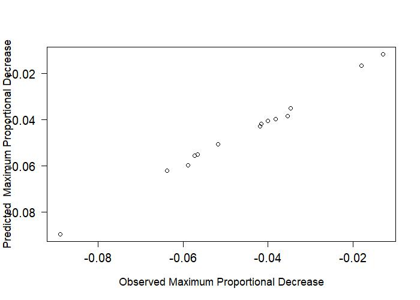

# 7 References

DWH MMIQT 2015, Models and analyses for the quantification of injury to Gulf of Mexico cetaceans from the Deepwater Horizon Oil Spill, MM_TR.01_Schwacke_Quantification.of.lnjury.to.GOM.Cetaceans [LINK](https://www.fws.gov/doiddata/dwh-ar-documents/876/DWH-AR0105866.pdf).

McLeod A, Xu C, Lai Y (2020). bestglm: Best Subset GLM and Regression Utilities. R package version 0.37.3, https://CRAN.R-project.org/package=bestglm.

Schwacke, L.H., L. Thomas, R.S. Wells, W.E. McFee, A.A. Hahn, K.D. Mullin, E.S. Zolman, B.M. Quigley, T.K. Rowles and J.H. Schwacke. 2017. An age-, sex- and class-structured population model for estimating nearshore common bottlenose dolphin injury following the Deepwater Horizon oil spill. *Endangered Species Research* **33**: 265-279. DOI: 10.3354/esr00777.